# Assignment 10: Annotation and Enrichment

**Name:** Ricardo Pineda  
**Student ID:** 917486212

Insert your answers below. Knit this file and submit the .Rmd and .html when you are done.

```r
library(tidyverse)
library(goseq)
library(rtracklayer)
library(GenomicRanges)
library(Biostrings)
```

**Exercise 1:**  
Import the gene descriptions that you downloaded; pay attention to the `read_tsv`“col_names” argument. What is appropriate here? Use one of the `join()` functions (which one?) to add gene descriptions for the genes found to be regulated by the DP treatment. Output a table of the top 10 genes (based on FDR) that includes the output from edgeR and the descriptions. Have the description be the first (left-most) column so that you can see it in the output (*Hint: use tidyverse `select`, but be sure to keep the other columns*)

```r
DEgene.trt <- read_csv("../input/DEgenes.trt.csv")
```

```
## ──────────────────────────────────────────────────────── Delimiter: "," chr
## (1): ...1 dbl (5): logFC, logCPM, LR, PValue, FDR
```

```r
#head(DEgene.trt)
colnames(DEgene.trt)[1] <- "GeneID" #rename colname
#head(DEgene.trt)

genedesc <- read_tsv("../input/FileS9.txt",col_names = c("GeneID", "description"))
#I have all the genes that are differentially express from the treatments, left join so I dont want to get rid of those just because they don't have an annotation.
DEgene.trt.desc <- left_join(DEgene.trt, genedesc, by = "GeneID")
DEgene.trt.desc <- select(DEgene.trt.desc, description, everything())
#DEgene.trt.desc

head(DEgene.trt.desc, 10)
```

| description | GeneID | logFC | logCPM | LR | PValue | FDR |
| --- | --- | --- | --- | --- | --- | --- |
| Phosphoglycerate mutase family protein | Bra028803 | -5.043456 | 3.514222 | 132.19855 | 1.353792e-30 | 3.253703e-26 |
| cysteine-rich RLK (RECEPTOR-like protein kinase) 5 | Bra019324 | 4.809736 | 2.209125 | 76.43637 | 2.274236e-18 | 2.732949e-14 |
| myb domain protein 69 | Bra034565 | 4.081287 | 2.159299 | 68.93415 | 1.018068e-16 | 8.156082e-13 |
| Protein of unknown function (DUF1645) | Bra025587 | 4.190919 | 3.298713 | 55.04401 | 1.178609e-13 | 7.081670e-10 |
| Cysteine proteinases superfamily protein | Bra029946 | 2.280844 | 5.364465 | 47.80174 | 4.715743e-12 | 1.898675e-08 |
| pleiotropic drug resistance 7 | Bra026156 | 1.764672 | 6.467797 | 47.50653 | 5.482101e-12 | 1.898675e-08 |
| Leucine-rich repeat transmembrane protein kinase | Bra030161 | 2.846792 | 5.105622 | 47.48949 | 5.529968e-12 | 1.898675e-08 |
| Plant invertase/pectin methylesterase inhibitor superfamily | Bra037739 | 2.041482 | 4.539958 | 47.09441 | 6.764834e-12 | 2.032325e-08 |
| Protein kinase superfamily protein | Bra016050 | 5.119232 | 1.755334 | 46.01184 | 1.175405e-11 | 3.138854e-08 |
| No annotation found | Bra029042 | 3.496552 | 1.240656 | 45.59894 | 1.451197e-11 | 3.487808e-08 |

**Exercise 2:**

```r
#Import go.terms, expressed genes, and gene lengths
go.terms <- read_tsv("../input/FileS11.txt",col_names=FALSE)
head(go.terms)
```

| X1 | X2 |
| --- | --- |
| Bra002000 | GO:0005488 |
| Bra001201 | GO:0000160,GO:0009927,GO:0000155,GO:0018106,GO:0005524,GO:0004740,GO:0005739 |
| Bra001122 | GO:0050832,GO:0016023,GO:0008061,GO:0042742 |
| Bra001115 | GO:0009825,GO:0001578,GO:0055028,GO:0007163,GO:0010031,GO:0010015,GO:0010091 |
| Bra001108 | GO:0000166,GO:0003723 |
| Bra001050 | GO:0070628,GO:0043130,GO:0005634 |

```r
colnames(go.terms) <- c("GeneID","GO")
head(go.terms)
```

| GeneID | GO |
| --- | --- |
| Bra002000 | GO:0005488 |
| Bra001201 | GO:0000160,GO:0009927,GO:0000155,GO:0018106,GO:0005524,GO:0004740,GO:0005739 |
| Bra001122 | GO:0050832,GO:0016023,GO:0008061,GO:0042742 |
| Bra001115 | GO:0009825,GO:0001578,GO:0055028,GO:0007163,GO:0010031,GO:0010015,GO:0010091 |
| Bra001108 | GO:0000166,GO:0003723 |
| Bra001050 | GO:0070628,GO:0043130,GO:0005634 |

```r
expressed.genes <- read_tsv("../input/internode_expressed_genes.txt")
head(expressed.genes)
```

| x |
| --- |
| Bra000002 |
| Bra000003 |
| Bra000005 |
| Bra000006 |
| Bra000007 |
| Bra000008 |

```r
names(expressed.genes) <- "GeneID"

gene.lengths <- read_tsv("../input/Brapa_CDS_lengths.txt")
head(gene.lengths)
```

| GeneID | Length |
| --- | --- |
| Bra000001 | 1515 |
| Bra000002 | 1089 |
| Bra000003 | 570 |
| Bra000004 | 375 |
| Bra000005 | 1434 |
| Bra000006 | 312 |

```r
#we need to reduce the gene.length data to only contain entries for those genes in our expressed.genes set.  We also need this as a vector
gene.lengths.vector <- gene.lengths$Length[gene.lengths$GeneID %in% expressed.genes$GeneID]
names(gene.lengths.vector) <- gene.lengths$GeneID[gene.lengths$GeneID %in% expressed.genes$GeneID]
head(gene.lengths.vector)
```

```
## Bra000002 Bra000003 Bra000005 Bra000006 Bra000007 Bra000008
##      1089       570      1434       312       711       882
```

```r
#Do the reverse to make sure everything matches up (it seems that we don't have length info for some genes?)
expressed.genes.match <- expressed.genes[expressed.genes$GeneID %in% names(gene.lengths.vector),]
```

```r
#format go.terms for goseq
go.list <- strsplit(go.terms$GO,split=",")
names(go.list) <- go.terms$GeneID
head(go.list)
```

```
## $Bra002000
## [1] "GO:0005488"
##
## $Bra001201
## [1] "GO:0000160" "GO:0009927" "GO:0000155" "GO:0018106" "GO:0005524"
## [6] "GO:0004740" "GO:0005739"
##
## $Bra001122
## [1] "GO:0050832" "GO:0016023" "GO:0008061" "GO:0042742"
##
## $Bra001115
## [1] "GO:0009825" "GO:0001578" "GO:0055028" "GO:0007163" "GO:0010031"
## [6] "GO:0010015" "GO:0010091"
##
## $Bra001108
## [1] "GO:0000166" "GO:0003723"
##
## $Bra001050
## [1] "GO:0070628" "GO:0043130" "GO:0005634"
```

```r
#Format gene expression for goseq

#for each gene in expressed gene, return FALSE if it is not in DEgene.trt and TRUE if it is.
DE.trt <- expressed.genes.match$GeneID %in% DEgene.trt$GeneID
names(DE.trt) <- expressed.genes.match$GeneID
head(DE.trt)
```

```
## Bra000002 Bra000003 Bra000005 Bra000006 Bra000007 Bra000008
##     FALSE     FALSE     FALSE     FALSE     FALSE     FALSE
```

```r
DE.trt <- as.numeric(DE.trt) #convert to 0s and 1s
head(DE.trt)
```

```
## [1] 0 0 0 0 0 0
```

```r
sum(DE.trt) # number of DE genes
```

```
## [1] 600
```

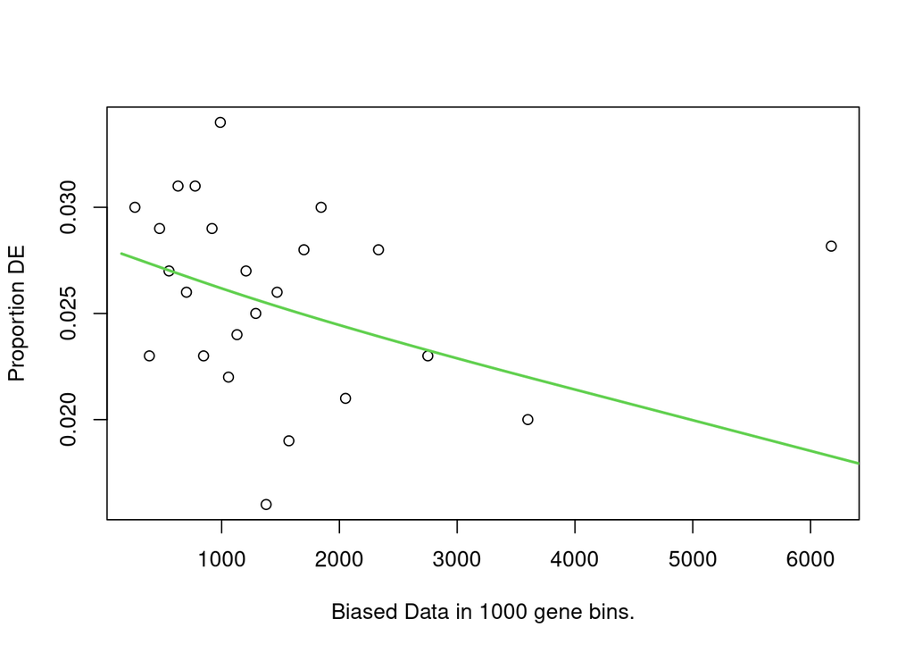

```r
#Calc GO terms

#determines if there is bias due to gene length.  The plot shows the relationship.
nullp.result <- nullp(DEgenes = DE.trt,bias.data = gene.lengths.vector)
```

```r
#calculate p-values for each GO term
rownames(nullp.result) <- names(gene.lengths.vector) #because of a bug in nullp()
GO.out <- goseq(pwf = nullp.result,gene2cat = go.list,test.cats=("GO:BP"))
```

```
## Using manually entered categories.
```

```
## For 3878 genes, we could not find any categories. These genes will be excluded.
```

```
## To force their use, please run with use_genes_without_cat=TRUE (see documentation).
```

```
## This was the default behavior for version 1.15.1 and earlier.
```

```
## Calculating the p-values...
```

```r
#list over-represented GO terms (p < 0.05)
GO.out[GO.out$over_represented_pvalue < 0.05,]
```

|  | category | over_represented_pvalue | under_represented_pvalue | numDEInCat | numInCat | term | ontology |
| --- | --- | --- | --- | --- | --- | --- | --- |
| 2830 | GO:0016891 | 0.003781109 | 0.9999348 | 2 | 4 | endoribonuclease activity, producing 5'-phosphomonoesters | MF |
| 440 | GO:0004222 | 0.004002419 | 0.9992307 | 6 | 61 | metalloendopeptidase activity | MF |
| 2850 | GO:0017025 | 0.004326176 | 0.9999201 | 2 | 4 | TBP-class protein binding | MF |
| 1132 | GO:0006397 | 0.006391324 | 0.9988895 | 5 | 47 | mRNA processing | BP |
| 2727 | GO:0016559 | 0.006584880 | 0.9994785 | 3 | 15 | peroxisome fission | BP |
| 3230 | GO:0031625 | 0.009508415 | 0.9986086 | 4 | 34 | ubiquitin protein ligase binding | MF |
| 1805 | GO:0009523 | 0.014074277 | 0.9984766 | 3 | 19 | photosystem II | CC |
| 2030 | GO:0009932 | 0.014509643 | 0.9983938 | 3 | 21 | cell tip growth | BP |
| 4382 | GO:0070588 | 0.017226888 | 0.9979481 | 3 | 23 | calcium ion transmembrane transport | BP |
| 4164 | GO:0051082 | 0.017465677 | 0.9933523 | 10 | 175 | unfolded protein binding | MF |

[output cut: 60 more lines]

```r
#Write out and save enriched genes
write.table(GO.out[GO.out$over_represented_pvalue < 0.05,1:2],row.names=FALSE,file="../output/GO_terms.txt", quote = FALSE,col.names = FALSE)
```

**a:** In REVIGO display a “TreeMap” of the BP GO terms. Take a screenshot and include it here.

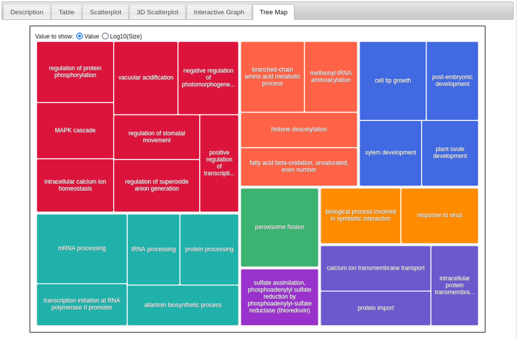

**b:** Remember that the genes used in this analysis are those that are differentially expressed between plants grown at high density (“DP”, multiple plants per pot) and not densely planted (“NDP”. one plant per pot). Plants in the DP treatment are able to sense their neighbors via photoreceptors that initiate a signaling cascade leading to more elongation growth. List two GO terms from this analysis that could be related to signaling or growth.

- `MAPK Signaling` could be related to signaling and `Cell tip growth` could be related to growth.

```r
#Import gff

# you may need to change the path or make a symbolic link
gff <- import.gff("../../assignment08-rhpineda/input/Brapa_reference/Brapa_gene_v1.5.gff")
gff
```

```
## GRanges object with 288624 ranges and 7 metadata columns:
##                  seqnames          ranges strand |   source     type      score
##                     <Rle>       <IRanges>  <Rle> | <factor> <factor>  <numeric>
##        [1]            A03 8794511-8797095      + |     blat     gene          1
##        [2]            A03 8794511-8797095      + |     blat     mRNA          1
##        [3]            A03 8794511-8794534      + |     blat     CDS         100
##        [4]            A03 8794622-8794805      + |     blat     CDS         100
##        [5]            A03 8795258-8795339      + |     blat     CDS         100
##        ...            ...             ...    ... .      ...      ...        ...
##   [288620] Scaffold005112         131-295      + |    blat      mRNA   1.000000
##   [288621] Scaffold005112         131-295      + |    blat      CDS  100.000000
##   [288622] Scaffold008211          18-251      + |    glean     gene   0.970334
##   [288623] Scaffold008211          18-251      + |    glean     mRNA   0.970334
##   [288624] Scaffold008211          18-251      + |    glean     CDS          NA
##                phase          ID        Name          Parent
##            <integer> <character> <character> <CharacterList>
##        [1]      <NA>   Bra000001   Bra000001
##        [2]      <NA>   Bra000001   Bra000001
##        [3]      <NA>        <NA>        <NA>       Bra000001
##        [4]      <NA>        <NA>        <NA>       Bra000001
##        [5]      <NA>        <NA>        <NA>       Bra000001
##        ...       ...         ...         ...             ...
##   [288620]      <NA>   Bra041173   Bra041173
##   [288621]      <NA>        <NA>        <NA>       Bra041173
##   [288622]      <NA>   Bra041174   Bra041174
##   [288623]      <NA>   Bra041174   Bra041174
##   [288624]         0        <NA>        <NA>       Bra041174
##   -------
##   seqinfo: 284 sequences from an unspecified genome; no seqlengths
```

```r
mRNAranges <- gff[gff$type=="mRNA",c("type", "ID")]
mRNAranges
```

```
## GRanges object with 41020 ranges and 2 metadata columns:
##                 seqnames          ranges strand |     type          ID
##                    <Rle>       <IRanges>  <Rle> | <factor> <character>
##       [1]            A03 8794511-8797095      + |     mRNA   Bra000001
##       [2]            A03 8797899-8800379      - |     mRNA   Bra000002
##       [3]            A03 8812470-8813271      + |     mRNA   Bra000003
##       [4]            A03 8816858-8817232      + |     mRNA   Bra000004
##       [5]            A03 8818081-8820123      - |     mRNA   Bra000005
##       ...            ...             ...    ... .      ...         ...
##   [41016] Scaffold004047          11-321      + |     mRNA   Bra041170
##   [41017] Scaffold004813         190-414      - |     mRNA   Bra041171
##   [41018] Scaffold004894           3-410      + |     mRNA   Bra041172
##   [41019] Scaffold005112         131-295      + |     mRNA   Bra041173
##   [41020] Scaffold008211          18-251      + |     mRNA   Bra041174
##   -------
##   seqinfo: 284 sequences from an unspecified genome; no seqlengths
```

```r
#We don't have scaffolds, only keep chromosomes

chromosomes <- c(paste0("A0", 1:9), "A10")
seqlevels(mRNAranges, pruning.mode="coarse") <- chromosomes
mRNAranges
```

```
## GRanges object with 39609 ranges and 2 metadata columns:
##           seqnames            ranges strand |     type          ID
##              <Rle>         <IRanges>  <Rle> | <factor> <character>
##       [1]      A03   8794511-8797095      + |     mRNA   Bra000001
##       [2]      A03   8797899-8800379      - |     mRNA   Bra000002
##       [3]      A03   8812470-8813271      + |     mRNA   Bra000003
##       [4]      A03   8816858-8817232      + |     mRNA   Bra000004
##       [5]      A03   8818081-8820123      - |     mRNA   Bra000005
##       ...      ...               ...    ... .      ...         ...
##   [39605]      A08 11283500-11285461      - |     mRNA   Bra040840
##   [39606]      A09 26845542-26846612      + |     mRNA   Bra041026
##   [39607]      A09 26848837-26850491      - |     mRNA   Bra041027
##   [39608]      A09   6389757-6392224      + |     mRNA   Bra041081
##   [39609]      A09   6394063-6397281      + |     mRNA   Bra041082
##   -------
##   seqinfo: 10 sequences from an unspecified genome; no seqlengths
```

**Exercise 3:** Flanking sequences could be defined in a variety of ways. We want `flank()` to take sequences upstream, not downstream of the mRNAs. Also, remember that genes can be transcribed from the “+” (upper) or “-” (lower) DNA strand. Thus we want `flank()` to take coding strand into consideration and take sequences that are upstream of the 5’ end of the gene. Examine the entries for the first two genes in the `mRNARanges` and `promoterRanges` to determine if `flank()` has done what we want. Explain how you know.

```r
#To compare with promotor regions
mRNAranges
```

```
## GRanges object with 39609 ranges and 2 metadata columns:
##           seqnames            ranges strand |     type          ID
##              <Rle>         <IRanges>  <Rle> | <factor> <character>
##       [1]      A03   8794511-8797095      + |     mRNA   Bra000001
##       [2]      A03   8797899-8800379      - |     mRNA   Bra000002
##       [3]      A03   8812470-8813271      + |     mRNA   Bra000003
##       [4]      A03   8816858-8817232      + |     mRNA   Bra000004
##       [5]      A03   8818081-8820123      - |     mRNA   Bra000005
##       ...      ...               ...    ... .      ...         ...
##   [39605]      A08 11283500-11285461      - |     mRNA   Bra040840
##   [39606]      A09 26845542-26846612      + |     mRNA   Bra041026
##   [39607]      A09 26848837-26850491      - |     mRNA   Bra041027
##   [39608]      A09   6389757-6392224      + |     mRNA   Bra041081
##   [39609]      A09   6394063-6397281      + |     mRNA   Bra041082
##   -------
##   seqinfo: 10 sequences from an unspecified genome; no seqlengths
```

```r
promoterRanges <- flank(mRNAranges, 1500)
promoterRanges
```

```
## GRanges object with 39609 ranges and 2 metadata columns:
##           seqnames            ranges strand |     type          ID
##              <Rle>         <IRanges>  <Rle> | <factor> <character>
##       [1]      A03   8793011-8794510      + |     mRNA   Bra000001
##       [2]      A03   8800380-8801879      - |     mRNA   Bra000002
##       [3]      A03   8810970-8812469      + |     mRNA   Bra000003
##       [4]      A03   8815358-8816857      + |     mRNA   Bra000004
##       [5]      A03   8820124-8821623      - |     mRNA   Bra000005
##       ...      ...               ...    ... .      ...         ...
##   [39605]      A08 11285462-11286961      - |     mRNA   Bra040840
##   [39606]      A09 26844042-26845541      + |     mRNA   Bra041026
##   [39607]      A09 26850492-26851991      - |     mRNA   Bra041027
##   [39608]      A09   6388257-6389756      + |     mRNA   Bra041081
##   [39609]      A09   6392563-6394062      + |     mRNA   Bra041082
##   -------
##   seqinfo: 10 sequences from an unspecified genome; no seqlengths
```

Below are the mRNA ranges and then the promoter ranges.

mRNA  
[1] A03 8794511-8797095 + | mRNA Bra000001  
[2] A03 8797899-8800379 - | mRNA Bra000002

PROMOTOR  
[1] A03 8793011-8794510 + | mRNA Bra000001  
[2] A03 8800380-8801879 - | mRNA Bra000002

I know flank is doing what it’s supposed to if I track what’s upstream as diagrammed below

[1] It’s in the right spot because the promoter is smaller than the mRNA on the + strand

- [0] 5 -Promoter [8793011-8794510]-mRNA [8794511-8797095]- 3
- [0] 3 ————————————————— 5

[2] It’s in the right spot because the promoter is larger than the mRNA on the - strand

- [0] 5 ————————————————— 3
- [0] 3 -mRNA [8797899-8800379]-Promoter [8800380-8801879]- 5

**Exercise 4:**

```r
#Import chromosome seqs
Brapaseq <- readDNAStringSet("../../assignment08-rhpineda/input/Brapa_reference/BrapaV1.5_chrom_only.fa")
#names(Brapaseq)

#remove unneeded info
names(Brapaseq) <- str_remove(names(Brapaseq), " \\[.*")
names(Brapaseq)
```

```
##  [1] "A01" "A02" "A03" "A04" "A05" "A06" "A07" "A08" "A09" "A10"
```

```r
#get promotor seqs
promoters <- Brapaseq[promoterRanges]
names(promoters) <- promoterRanges$ID
#promoters

#clean promotors | Remove N so motifs won't match them
promoters <- DNAStringSet(gsub("N","-",promoters))
promoters
```

```
## DNAStringSet object of length 39609:
##         width seq                                           names
##     [1]  1500 TATCATTCTCCCAAACCCAAA...AGAGCGTTCTATTGCAGAAAC Bra000001
##     [2]  1500 CTTAGATAATAACTTTAGATC...TTATTTAGTATTTTTTTTTTT Bra000002
##     [3]  1500 TCTAAGTAACCAGGGCGTTAG...CTTCTCTTGCTTTAGCTGGAT Bra000003
##     [4]  1500 AAATGTATTCACGATTGTGTT...GCTTTAAGAAGCAACCTTTCG Bra000004
##     [5]  1500 CGTGGCTCCGATCACCGAGTG...TAGAAAACATCAATCTTTTTA Bra000005
##     ...   ... ...
## [39605]  1500 AATATCTCTGGTTTAGTACAT...GTAAAAGACACAGGTGATTTA Bra040840
## [39606]  1500 GAGATAACTTACACGAAGACT...CGTCTCAGGATGCTCTGGATC Bra041026
## [39607]  1500 TAACAAAATTATATGAGCTCT...TTATATATTTTCCTTAATTTT Bra041027
## [39608]  1500 ---------------------...AAAACCAAAGTAAGTTGAACA Bra041081
## [39609]  1500 GAAGCGGATACTCGTAATCAT...CAAATCTCTCTCTCTTCTTCC Bra041082
```

```r
#Load TF binding motifs
#wget https://bis180ldata.s3.amazonaws.com/downloads/RNAseq_Annotation/element_name_and_motif_IUPACsupp.txt
```

```r
#Format motifs
motifs <- read.delim("../input/element_name_and_motif_IUPACsupp.txt",header=FALSE,as.is=TRUE)
head(motifs)
```

|  | V1 | V2 |
| --- | --- | --- |
| 1 | ABFs binding site motif | CACGTGGC |
| 2 | ABRE binding site motif | YACGTGGC |
| 3 | ABRE-like binding site motif | BACGTGKM |
| 4 | ACE promoter motif | GACACGTAGA |
| 5 | AG binding site motif | TTDCCWWWWWWGGH |
| 6 | AG BS in AP3 | CCATTTTTAGT |

```r
motifsV <- as.character(motifs[,2])
names(motifsV) <- motifs[,1]
motifsSS <- DNAStringSet(motifsV)
motifsSS
```

```
## DNAStringSet object of length 100:
##       width seq                                             names
##   [1]     8 CACGTGGC                                        ABFs binding site...
##   [2]     8 YACGTGGC                                        ABRE binding site...
##   [3]     8 BACGTGKM                                        ABRE-like binding...
##   [4]    10 GACACGTAGA                                      ACE promoter motif
##   [5]    14 TTDCCWWWWWWGGH                                  AG binding site m...
##   ...   ... ...
##  [96]     5 GGGCC                                           SORLIP2
##  [97]     9 CTCAAGTGA                                       SORLIP3
##  [98]     9 GTATGATGG                                       SORLIP4
##  [99]     7 GAGTGAG                                         SORLIP5
## [100]    11 YCYAACGGYYA                                     MSA
```

```r
#Subsetting differentially expressed genes and those that arent differentially expressed

#get names to match...there are are few names in the DEgene list not in the promoter set
DEgene.trt.match <- DEgene.trt$GeneID[DEgene.trt$GeneID %in% names(promoters)]

expressed.genes.match <- expressed.genes$GeneID[expressed.genes$GeneID %in% names(promoters)]

#subset promoter files
universe.promoters <- promoters[expressed.genes.match]
target.promoters <- promoters[DEgene.trt.match]
non.target.promoters <- universe.promoters[
  ! names(universe.promoters) %in% names(target.promoters)] # all expressed genes not in target set
```

```r
#looking for overrepresented motifs
#motifsSS[2] #Testing the second motif from the database

#Counting the occurences of a motif
target.counts <- vcountPDict(motifsSS[2],
            subject = target.promoters,
            fixed = FALSE) #fixed = FALSE allows IUPAC ambiguity codes
#Results from above
dim(target.counts) #1 row for each motif, 1 column for each sequence that we are searching
```

```
## [1]   1 586
```

```r
target.counts[1,1:20] # each cell contains the counts for a particular motif in a particular sequence
```

```
##  [1] 0 0 0 0 0 0 0 0 0 0 0 1 0 0 1 0 0 0 0 0
```

```r
#Searching both strands of DNA for occurences of a motif
target.counts <-
  vcountPDict(motifsSS[2],
            subject = target.promoters,
            fixed = FALSE) +
    vcountPDict(motifsSS[2],
            subject = reverseComplement(target.promoters),
            fixed = FALSE)
#Results from above
target.total <- rowSums(target.counts>0)
target.total
```

```
## [1] 42
```

```r
length(target.promoters) - target.total
```

```
## [1] 544
```

```r
# of 586 differentially expressed genes,42 w/ motif, 544 w/o
#[1] 42
#[1] 544

#Finding the number of promoters that werent differentially expressed w/ the motif
non.target.counts <- vcountPDict(motifsSS[2],
            subject = non.target.promoters,
            fixed = FALSE) +
    vcountPDict(motifsSS[2],
            subject = reverseComplement(non.target.promoters),
            fixed = FALSE)
non.target.total <- rowSums(non.target.counts > 0)
non.target.total
```

```
## [1] 1559
```

```r
length(non.target.promoters) - non.target.total
```

```
## [1] 20607
```

```r
# of 22166 expressed genes not differentially expressed, 1559 have 1+ copies of the motif, 20607 w/o the motif
#[1] 1559
#[1] 20607
```

```r
#Determining enrichment, using Fisher's exact test
#Contingency Table w/ counts
m <- matrix(c(
  target.total,
  length(target.promoters) - target.total,
  non.target.total,
  length(non.target.promoters) - non.target.total ),
  ncol=2,
  dimnames = list(motif=c("Y", "N"), target=c("Y", "N")))
m
```

```
##      target
## motif   Y     N
##     Y  42  1559
##     N 544 20607
```

```r
#Running test
fisher.test(m)
```

```
##
##  Fisher's Exact Test for Count Data
##
## data:  m
## p-value = 0.87
## alternative hypothesis: true odds ratio is not equal to 1
## 95 percent confidence interval:
##  0.7240326 1.4047745
## sample estimates:
## odds ratio
##   1.020516
```

```r
#create a function to summarize the results and test for significance
motifEnrichment <- function(target.promoters,non.target.promoters,all.counts=F,motifs=motifsSS) {

  #use vcountPDict to count the occurrences of each motif in each promoter
  target.counts <- vcountPDict(motifs,target.promoters,fixed=F) +
    vcountPDict(motifsSS,reverseComplement(target.promoters),fixed=F)
  non.target.counts <- vcountPDict(motifs,non.target.promoters,fixed=F) +
    vcountPDict(motifsSS,reverseComplement(non.target.promoters),fixed=F)

  if (all.counts) {
    #count all occurrences of a motif instead of the number of promoters that it occurs in
    target.counts.sum <- rowSums(target.counts)
    non.target.counts.sum <- rowSums(non.target.counts)
  } else {
    target.counts.sum <- rowSums(target.counts > 0)
    non.target.counts.sum <- rowSums(non.target.counts > 0)
  }
  n.motifs <- length(target.counts.sum)
  results <- vector(mode="numeric",length=n.motifs)
  for (i in 1:n.motifs) {
    if (all.counts) { #the contigency tables are different depending on whether we are looking at promoters or overall occurrences
      #test if ratio of occurrences to promoters is the same in the target and the non.target
      m <- matrix(c(
        target.counts.sum[i],                       #number of occurrences within target
        dim(target.counts)[2],                      #number of promoters in target
        non.target.counts.sum[i],                  #number of occurrences within non.target
        dim(non.target.counts)[2]                  #number of promoters in non.target
      ),ncol=2)
    } else { #looking at promoters with and without hits
      m <- matrix(c(
        target.counts.sum[i],                        #number of promoters in target with hit
        dim(target.counts)[2]-target.counts.sum[i],            #number of promoters in target with no hit
        non.target.counts.sum[i],                   #number of promoters in non.target with hit
        dim(non.target.counts)[2]-non.target.counts.sum[i]   #number of promoters in non.target with no hit
      ),ncol=2)
    } #else
    results[i] <- fisher.test(m,alternative="greater")$p.value
  } #for loop
  results.table <- data.frame(
    motif=names(motifs),
    non.target.percent = round(non.target.counts.sum/dim(non.target.counts)[2],3)*100,
    target.percent = round(target.counts.sum/dim(target.counts)[2],3)*100,
    p.value =  results)
  results.table <- results.table[order(results.table$p.value),]
  results.table
}
```

```r
motif.results <- motifEnrichment(target.promoters, non.target.promoters)
head(motif.results)
```

|  | motif | non.target.percent | target.percent | p.value |
| --- | --- | --- | --- | --- |
| 92 | SORLREP3 | 14.2 | 20.1 | 6.730386e-05 |
| 20 | AtMYC2 BS in RD22 | 48.7 | 56.3 | 1.503921e-04 |
| 75 | RY-repeat promoter motif | 3.4 | 5.5 | 7.892045e-03 |
| 56 | LS5 promoter motif | 0.1 | 0.5 | 1.398259e-02 |
| 88 | ATB2/AtbZIP53/AtbZIP44/GBF5 BS in ProDH | 53.3 | 57.8 | 1.580989e-02 |
| 72 | PRHA BS in PAL1 | 0.0 | 0.2 | 2.575598e-02 |

**a.** How many motifs are enriched at P < 0.05? (Can you do this with code?)

There are 12 motifs enriched at P < 0.05

```r
motif.results.filtered <- motif.results %>%
    filter(p.value < 0.05)
motif.results.filtered
```

| motif | non.target.percent | target.percent | p.value |
| --- | --- | --- | --- |
| SORLREP3 | 14.2 | 20.1 | 6.730386e-05 |
| AtMYC2 BS in RD22 | 48.7 | 56.3 | 1.503921e-04 |
| RY-repeat promoter motif | 3.4 | 5.5 | 7.892045e-03 |
| LS5 promoter motif | 0.1 | 0.5 | 1.398259e-02 |
| ATB2/AtbZIP53/AtbZIP44/GBF5 BS in ProDH | 53.3 | 57.8 | 1.580989e-02 |
| PRHA BS in PAL1 | 0.0 | 0.2 | 2.575598e-02 |
| Bellringer/replumless/pennywise BS2 IN AG | 17.7 | 20.8 | 3.141220e-02 |
| Bellringer/replumless/pennywise BS3 IN AG | 17.7 | 20.8 | 3.141220e-02 |
| MYB binding site promoter | 43.2 | 47.1 | 3.416977e-02 |
| G-box promoter motif | 22.0 | 25.3 | 3.683160e-02 |

[output cut: 2 more lines]

```r
#count(motif.results.filtered)
```

**b.** What is the identity of the most significantly over-enriched promoter? (No code)

- SORLREP3

**c.** What percentage of genes in the “non.target” have this motif? What percentage in our target set? (No code)

- `non.target` : 14.2
- `target.percent` : 20.1

**d.** You can find information on the motifs [here](http://arabidopsis.med.ohio-state.edu/AtcisDB/bindingsites.html). Remembering that plants in the “DP” treatment experience shading from their neighbors, where as “NDP” plants do not. Do you think that the most enriched motif represents a biologically relevant result? Discuss why or why not.

- Yes! The description for the motif is “Identification of key promoter motifs involved in the network of light-regulated gene expression by combined analysis of genomic sequence and microarray data.” One possible scenario where this motif is biologically relevant is where photomorphogenesis genes that control processes like shade avoidance response could be activated more in DP versus NDP, or the other way around where they are inhibited in NDP while active in DP. Either way they should be different since this motif is associated with light-regulated gene expression and the different treatments have different levels of light due to planting density.